# Week 3 Markdown Tutorial

Cassondra Walker

## Bio for Cassondra Walker

I am a PhD candidate in the Department of Integrative Biology at Oklahoma State University.

### Interests

> I study how environmental conditions operate at different spatial scales (extent and grain) to constrain species distributions. I use remotely sensed data to quantify environmental conditions across differing spatial extents and resolutions. I currently collect my own terrestrial LiDAR to quantify vertical structure at fine spatial scales. I am also interested in the scaling properties of LiDAR derived metrics; for example, how airborne collected point clouds can be modeled to terrestrial collected point clouds.

### About My Proposed Capstone Project

> My project idea is to model Leaf Area Index at large spatial extents at varying resolutions. I would like to develop a procedure to model the relationship between Leaf Area Index and Normalized Difference Vegetation Index for the Great Plains (North, Central, and Southern Plains NEON Domains), where I conduct most of my research. Since LAI is not readily available at fine spatial resolutions, I would like to develop a procedure that will allow me to estimate LAI values from known NDVI values. By using NDVI and LAI products from the NEON dataset, I can develop a model mathematically describing the relationship between these two vegetation indices. I can then use this constructed model to derive LAI values from other NDVI datasets (i.e. Landsat).

## Week Three Tutorial-Working with LiDAR Data

### Load R libraries

```r
library(rgdal)
library(raster)
library(colorspace)
```

The libraries **rgdal** and **raster** are packages for working with raster data. The package **colorspace** allows for coloring options for the raster plots.

### Set Working Directory

```r
setwd("~/Documents/NEON")
```

### Load Lidar DSM file

```r
teakdsm<-raster("~/Documents/NEON/Data/NEONDI2016TEAK/NEONdata/D17-California/TEAK/2013/lidar/TEAK_lidarDSM.tif")
```

A Digital Surface Model is a representation of the surface of a study region. Heights are shown as elevations.

### Plot the LiDAR Digital Surface Model

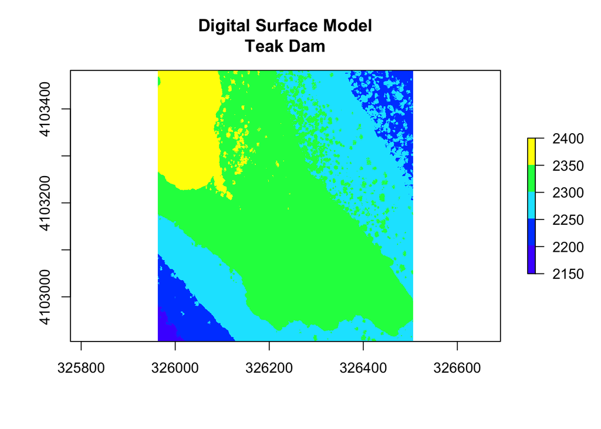

```r
plot(teakdsm,
     breaks=c(2150,2200,2250,2300,2350,2400),
     col=topo.colors(5),
     main="Digital Surface Model\nTeak Dam")
```

The Digital Surface Model shows that most of the surface heights in our study area range between 2150 - 2400 m above sea level.

### Load LiDAR Canopy Height Model

```r
teakchm<-raster("~/Documents/NEON/Data/NEONDI2016TEAK/NEONdata/D17-California/TEAK/2013/lidar/TEAK_lidarCHM.tif")
```

A Canopy Height Model shows the height of trees in the study areas.

### Plot LiDAR Canopy Height Model

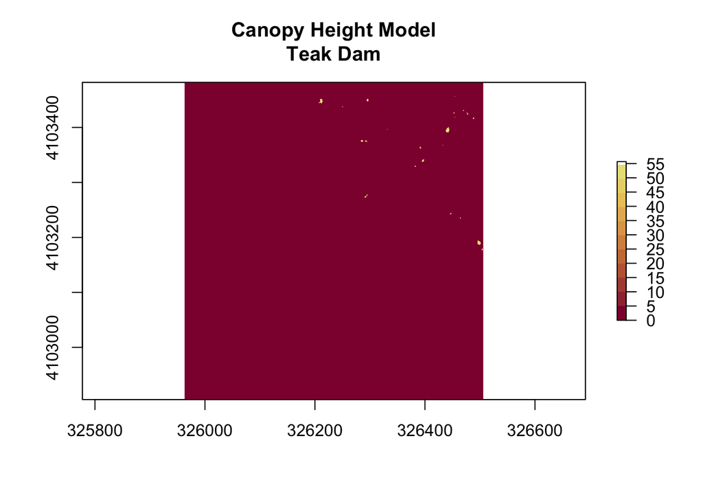

```r
plot(teakchm,
     breaks=c(0,5,10,15,20,25,30,35,40,45,50,55),
     col=heat_hcl(12,c=c(80,30),l=c(30,90),power=c(1/5,1.5)),
     main="Canopy Height Model\nTeak Dam")
```

From our canopy height model, we can see that the study area does not have many trees, just a few patches which are about 55 m high.

### Create Histograms for both LiDAR datasets

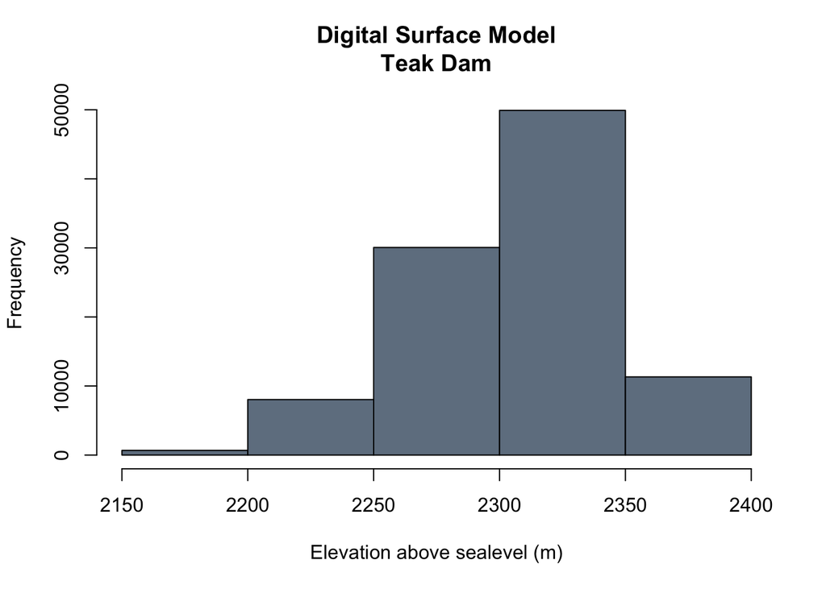

```r
DSMhist<-hist(teakdsm,
              breaks=6,
              main="Digital Surface Model\nTeak Dam",
              col="slategray",
              xlab="Elevation above sealevel (m)")
```

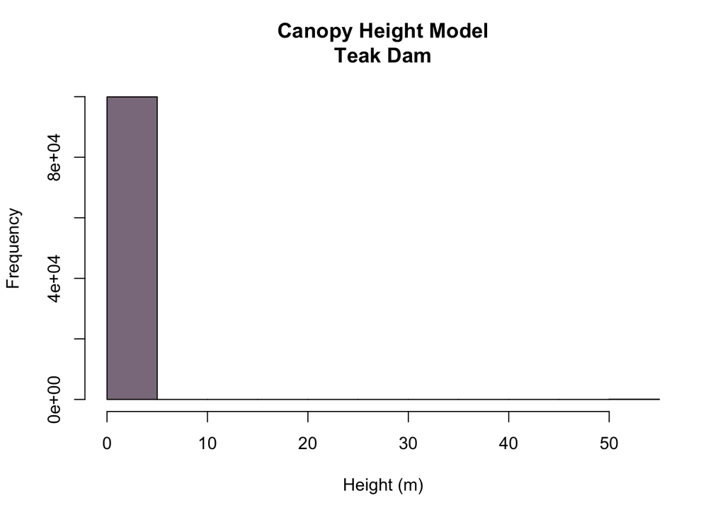

```r
CHMhist<-hist(teakchm,
              breaks=12,
              main="Canopy Height Model\nTeak Dam",
              col="thistle4",
              xlab="Height (m)")
```